# Week 5: Syntax Guide

- Week 5: Syntax Guide
  - Array Declaration
  - Array Initialisation
  - Accessing values in an array
  - For Loops
  - Generics
  - foreach loop:

## Array Declaration

the `[]` brackets go after the type, to indicate that we have an array of the preceding type.

```
int[] values;
string[] names;
```

## Array Initialisation

We can initialise our arrays when we declare them with the following syntax:

```
int[] temperatures = new int[5];
int[] temperatures = new int[3] { 22, 23, 24 };
string[] names = new string[3] { "Steven", "Alex", "Andrew" };
```

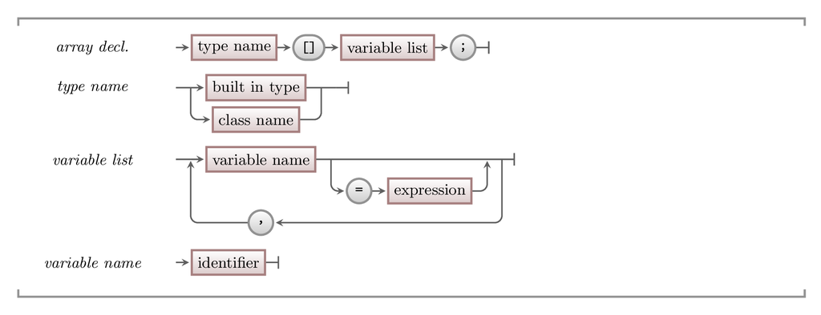

This diagram shows the syntax for an array declaration and initialisation in C#.

- Note that values or expressions must all be of a type which matches the type of array. Above, our `int` array of temperatures stores 22, 23, 24 (all integers).

## Accessing values in an array

We can access individual values in our arrays with the following syntax:

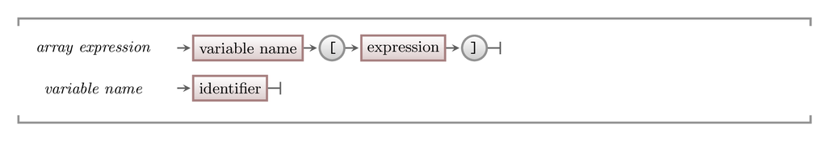

This diagram shows the syntax for an array expression in C#.

```
int[] temperatures = new int[3] { 22, 23, 24 };

temperatures[2];

int i = 3;
temperatures[i]
temperatures[i + 2]
```

## For Loops

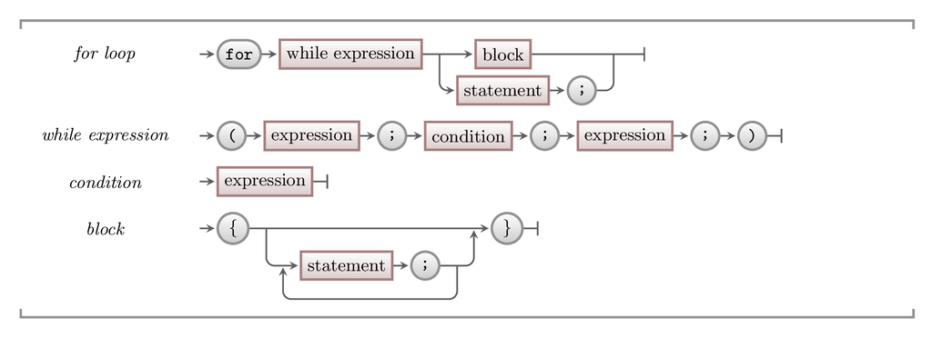

This diagram shows the syntax for a for loop in C#.

The for loop is most often constructed with the following components which are separated by a semicolon `;` in the brackets:

- init - runs once before the loop starts.
- while - the condition of the loop, checked each iteration.
- post loop action - runs at the end of each loop.

```
int[] temperatures = { 22, 22, 23, 24, 24, 22 };
for ( int i; i < temperatures.Length; i++ )
{
   Console.WriteLine(temperatures[i]);
}

int i = 0;
while (i < temperatures.Length;)
{
   Console.WriteLine(temperatures[i]);
   i++;
}
```

*note*: The for and while loops in the examples above are equivalent.

## Generics

Generics are used when a class needs to use or manage objects of some type, where the specifics of the type will be provided by the user of the class. For example the *List* class needs us to specify what type we want to store in the list. This way, the List class can store lists of *any* type!

```
List<int> list1;
List<string> names;
List<decimal> prices;
List<SpaceShip> ships;
```

Generics are specified with the syntax `List<T>`, where `<T>` represents the position we specify the type. Wherever you see a `<T>`, it is the placeholder for a type.

You can also initialise lists with array contents as shown below. More details from [msdn](https://msdn.microsoft.com/en-us/library/bb384062.aspx).

```
List<int> temperatures = new List<int>() { 22, 32, 44 };
```

## foreach loop:

- foreach loops are a handy way for us to more easily loop over arrays and lists. They handle the index variable for us, and are an alternative syntax to for loops.

*Note*: Sometimes you still want an index variable, so you could use a for loop wherever you can use a foreach loop.

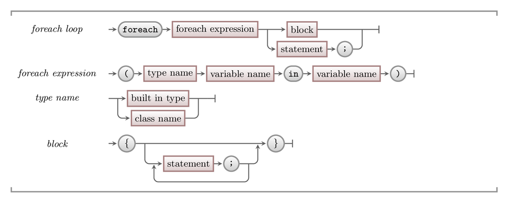

This diagram shows the syntax for a foreach loop in C#.

```
int[] temperatures = { 22, 22, 23, 24, 24, 22 };
foreach (int temp in temperatures)
{
   Console.WriteLine(temp);
}
```

A foreach loop is constructed with the following components:

- A type (`int`) is the type of element in your array or list.
- the `temp` is the name of the variable used in the loop, equivalent to `temperatures[i]`
- the name of the array/list: `in temperatures`.

*For more advanced array concepts, we can have 2 dimensional arrays:*

```
string[,] names;
```

*And jagged 2D arrays:*

```
int[][] values;
```

Read more on 2D arrays at [msdn](https://msdn.microsoft.com/en-us/library/2yd9wwz4.aspx).